# TidyModels Playaround

Leonard Seok

24 May 2020

Lets load the PimaIndiansDiabetes dataset for this play-around

```r
# A custom function to install and load packages
install.custom <- function(package.name) {
  if (!(package.name %in% rownames(installed.packages()))) {
    install.packages(package.name)
  } else {
    print(paste0(package.name," ","is already installed"))
  }
  library(package.name, character.only = T)
}

install.custom("purrr")
list_package <- list("mlbench", "dplyr", "tidyverse", "ggplot2", "parsnip")
map(list_package, ~install.custom(.x))
data("PimaIndiansDiabetes") # Load the data

data <- PimaIndiansDiabetes
```

Investigate the Numeric data with some histograms

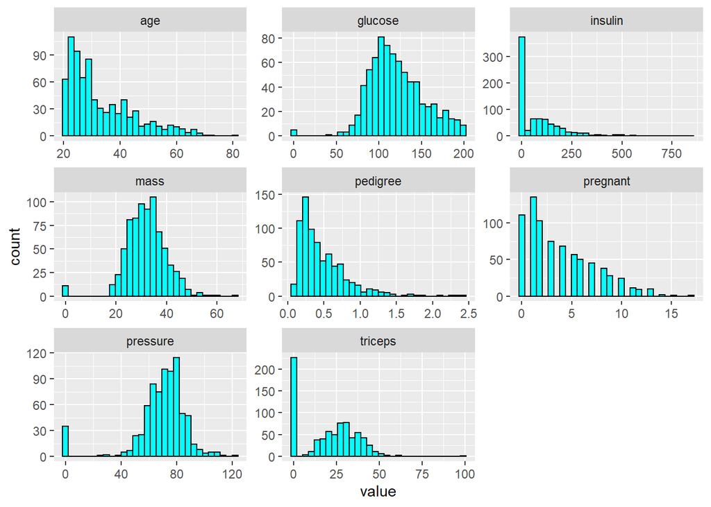

```r
data %>% dplyr::select_if(is.numeric) %>%
  gather(key='field', value='value') %>%
  ggplot(aes(x=value)) + geom_histogram(color='black',fill='cyan') +
  facet_wrap(~field, scales = 'free')
```

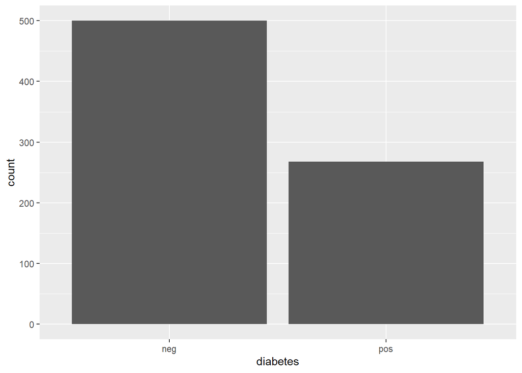

```r
data %>% ggplot(aes(x=diabetes)) + geom_bar()
```

For all fields other than pregnant and diabetes, lets set 0 to be NA

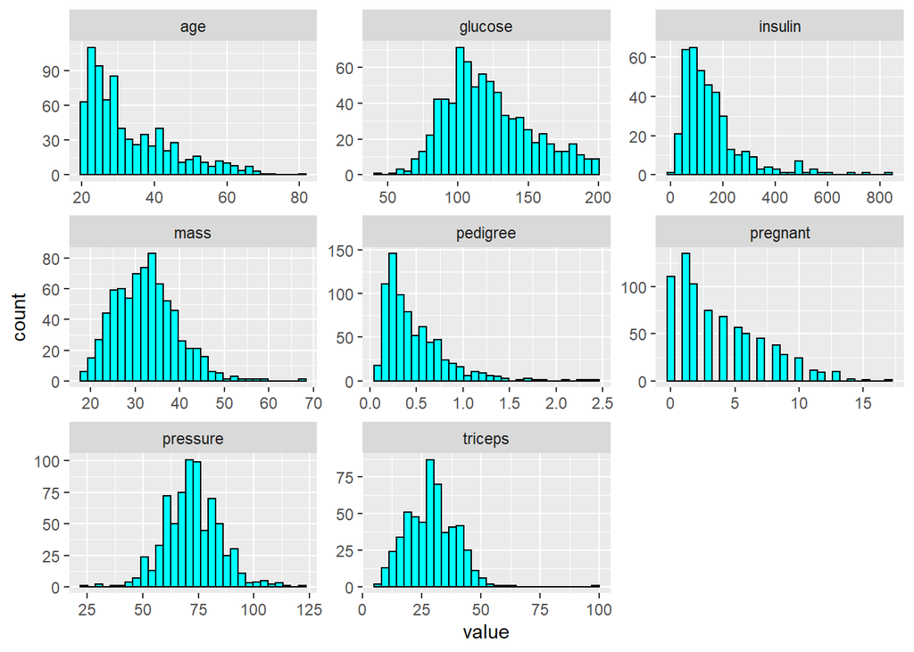

```r
d1 <- data %>% select(-pregnant,-diabetes) %>%
  map_dfr(~ifelse(.x==0,NA,.x))

d2 <- data %>% select(pregnant, diabetes) %>%
  mutate(diabetes = as.factor(ifelse(diabetes=='pos',1,0)))

data_clean <- cbind(d1, d2)

data_clean %>% select_if(is.numeric) %>%
  gather(key='key', value = 'value') %>%
  ggplot(aes(x=value)) + geom_histogram(color='black', fill='cyan') +
  facet_wrap(~key, scales = 'free')
```

## Modelling with TidyModels

Splitting the data into train and test sets

```r
set.seed(101)

data_ttsplit <- rsample::initial_split(data_clean, prop=0.75)
train <- rsample::training(data_ttsplit)
test <- rsample::testing(data_ttsplit)
```

We will now create cross fold validation, so that we can tune the model parameters. Here we create a 10 fold cross val:

```r
data_cv <- rsample::vfold_cv(train, v=10)
```

Next we shall define the the formula (the response and the predictor variables), as well as any pre-processing steps required. See here for more recipes https://recipes.tidymodels.org/articles/Custom_Steps.html

```r
recipe1 <- recipes::recipe(diabetes ~ ., data = train) %>%
  recipes::step_normalize(recipes::all_numeric()) %>%
  recipes::step_knnimpute(recipes::all_predictors()) # ?selection for other role sections

recipe1
```

```
## Data Recipe
##
## Inputs:
##
##       role #variables
##    outcome          1
##  predictor          8
##
## Operations:
##
## Centering and scaling for recipes::all_numeric
## K-nearest neighbor imputation for recipes::all_predictors
```

We can extract the pre-processed dataset to view what it looks like, albeit it being unnessary when fitting

```r
train_pp <- recipe1 %>% recipes::prep(train) %>%
  recipes::juice()
```

- Normalised the numeric data to have a mean of 0 and SD of 1
- imputed missing data using the K-Nearest Neighbour method

Lets create some model objects, note that this is still not actually fitting the model itself

```r
# Logistic model object
log_reg_mod <- logistic_reg() %>%
  set_engine("glm") %>%
  set_mode("classification")

# Random Forest Object
rf_mod <- rand_forest() %>%
  set_args(mtry=tune(), trees = tune()) %>% # mtry and tree are the parm that we have decide to tune
  set_engine("ranger", importance = "impurity") %>%
  set_mode("classification")
```

Now we put the recipe and the model object into a workflow

```r
rf_mod_wf <- workflows::workflow() %>%
  workflows::add_recipe(recipe1) %>%
  workflows::add_model(rf_mod)
```

Using this workflow and the Cross fold validation, we will tune the mtry and tree parm

```r
install.custom("yardstick")
```

```
## [1] "yardstick is already installed"
```

```
## For binary classification, the first factor level is assumed to be the event.
## Set the global option `yardstick.event_first` to `FALSE` to change this.
```

```r
rf_grid <- expand.grid(mtry=3:6, trees = c(200,300,500))

rf_tune_results <- rf_mod_wf %>%
  tune::tune_grid(resamples = data_cv
            , grid = rf_grid
            , metrics = metric_set(accuracy, roc_auc))
```

```
## i Creating pre-processing data to finalize unknown parameter: mtry
```

```r
rf_tune_results %>%
  tune::show_best(metric = "accuracy") %>%
  knitr::kable()
```

| mtry | trees | .metric | .estimator | mean | n | std_err |
| --- | --- | --- | --- | --- | --- | --- |
| 4 | 500 | accuracy | binary | 0.7605868 | 10 | 0.0142767 |
| 3 | 300 | accuracy | binary | 0.7587719 | 10 | 0.0131080 |
| 3 | 500 | accuracy | binary | 0.7554144 | 10 | 0.0138829 |
| 6 | 300 | accuracy | binary | 0.7553842 | 10 | 0.0165666 |
| 3 | 200 | accuracy | binary | 0.7536298 | 10 | 0.0130520 |

```r
rf_tune_results %>%
  tune::show_best(metric = "roc_auc") %>%
  knitr::kable()
```

| mtry | trees | .metric | .estimator | mean | n | std_err |
| --- | --- | --- | --- | --- | --- | --- |
| 4 | 300 | roc_auc | binary | 0.8307784 | 10 | 0.0169668 |
| 4 | 500 | roc_auc | binary | 0.8303926 | 10 | 0.0167869 |
| 3 | 500 | roc_auc | binary | 0.8289448 | 10 | 0.0174685 |
| 6 | 200 | roc_auc | binary | 0.8285452 | 10 | 0.0177589 |
| 3 | 200 | roc_auc | binary | 0.8281991 | 10 | 0.0171368 |

Based on both metrics, we can see that mtry = 4 and trees = 500 seem to be the best performing We shall create a dataframe for the parameter that we will use for our final model

```r
parm_fin <- tibble(mtry = 4, trees = 500)

# and then we add it to our workflow

rf_mod_wf <- rf_mod_wf %>% finalize_workflow(parm_fin)
rf_mod_wf
```

```
## == Workflow ======================================================================================================================================
## Preprocessor: Recipe
## Model: rand_forest()
##
## -- Preprocessor ----------------------------------------------------------------------------------------------------------------------------------
## 2 Recipe Steps
##
## * step_normalize()
## * step_knnimpute()
##
## -- Model -----------------------------------------------------------------------------------------------------------------------------------------
## Random Forest Model Specification (classification)
##
## Main Arguments:
##   mtry = 4
##   trees = 500
##
## Engine-Specific Arguments:
##   importance = impurity
##
## Computational engine: ranger
```

Now we can finally fit the model to our training, and then score it on the test.

```r
rf_fitted <- rf_mod_wf %>% last_fit(data_ttsplit)
```

We can then simply check the test set performance

```r
rf_fitted %>% collect_metrics()
```

```
## # A tibble: 2 x 3
##   .metric  .estimator .estimate
##   <chr>    <chr>          <dbl>
## 1 accuracy binary         0.75
## 2 roc_auc  binary         0.823
```

We can also generate predictions from the test set scoring

```r
test_preds <- rf_fitted %>% collect_predictions()

# Subsequently, we can also generate a confusion metric
test_preds %>% yardstick::conf_mat(truth=diabetes, estimate=.pred_class)
```

```
##           Truth
## Prediction   0   1
##          0 102  29
##          1  19  42
```

We will now plot the ROC / Gini curve

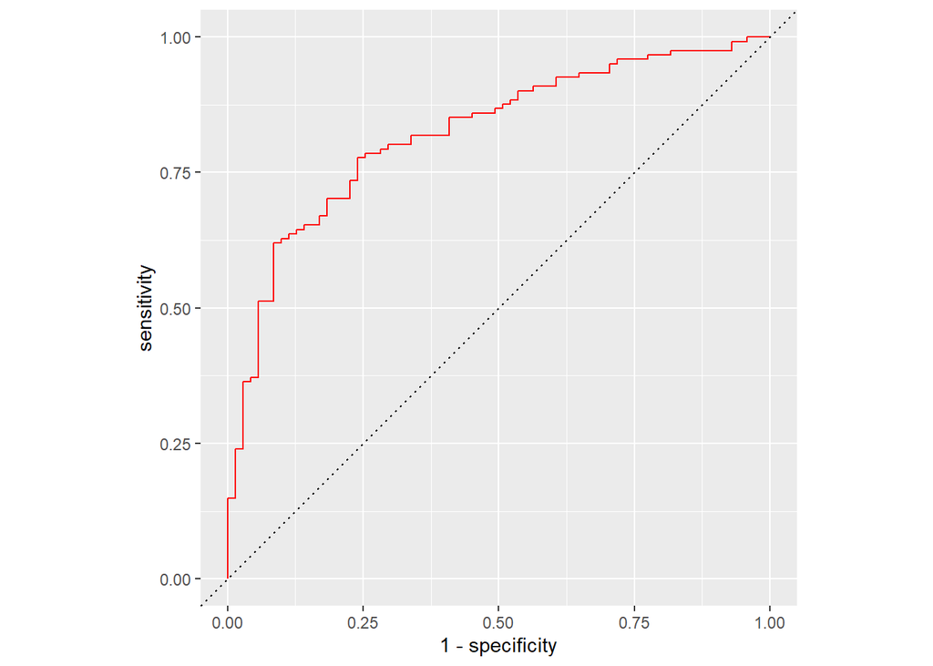

```r
rf_roc <- test_preds %>% yardstick::roc_curve(truth=diabetes,estimate=.pred_1)

rf_roc %>% ggplot(aes(x=1-specificity, y=sensitivity)) + geom_path(color='red') +
  geom_abline(lty=3) +
  coord_equal()
```

```r
# Obtaining the ROC - this should match with the collected metrics above
yardstick::roc_auc(test_preds, truth=diabetes, .pred_1)
```

```
## # A tibble: 1 x 3
##   .metric .estimator .estimate
##   <chr>   <chr>          <dbl>
## 1 roc_auc binary         0.823
```

We can also plot the probability distributions

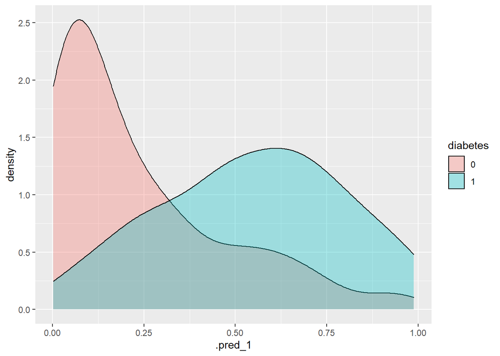

```r
test_preds %>% ggplot(aes(x=.pred_1)) + geom_density(aes(fill=diabetes), alpha = 1/3)
```

Once we are happy with the test set performance, we can then train our model on the full dataset and predict on new data.

```r
rf_mod_FIN <- fit(rf_mod_wf, data_clean)
```

Say we define some new data

```r
new_dat <- tribble(~pregnant, ~glucose, ~pressure, ~triceps, ~insulin, ~mass, ~pedigree, ~age,
                     3, 51, 90, 21, 200, 13.3, 0.62, 50,
                     4, 80, 90, 40, 85, 50.5, 0.8, 26)

predict(rf_mod_FIN, new_data = new_dat, type = 'prob')
```

```
## # A tibble: 2 x 2
##   .pred_0 .pred_1
##     <dbl>   <dbl>
## 1   0.849   0.151
## 2   0.681   0.319
```

```r
predict(rf_mod_FIN, new_data = new_dat, type = 'class')
```

```
## # A tibble: 2 x 1
##   .pred_class
##   <fct>
## 1 0
## 2 0
```

We can see that both predictions are No diabetes.

# Next Steps

We shall continue this by trying an XGBoost and a usual log reg, and see how this compares to our RF model! https://www.r-bloggers.com/using-xgboost-with-tidymodels/